# gRNA guide assignment: a Poisson-ambient model, and the reality of the lower count mode

Why the background contamination is Poisson, a method (fishash+) that exploits it, and what the ambiguous low counts actually are

Author

SCEPTRE3 guide-assignment investigation

Published

July 4, 2026

## Summary

In a single-cell CRISPR screen, each cell should be labeled with the guide RNA(s) it received. The raw data is a count of each guide’s UMIs in each cell, and the problem is that a guide shows up at low counts in many cells that never received it — ambient contamination. **Guide assignment** is the decision, for every (guide, cell) pair, of whether the observed count is real signal or contamination. This note reports what we have found about that background and the ambiguous low counts, the method that follows, and its practical consequence.

1. **The contamination is Poisson.** On a ground-truth benchmark (a human/mouse cell mixture) the background counts follow a Poisson distribution whose rate scales with each cell’s contamination level. This holds even for the direct-capture chemistry, which a recent method (CLEANSER) modeled as over-dispersed; we show that apparent over-dispersion is two mundane effects, not soup dispersion — **cell doublets** (most excluded once the standard purity gate is tightened from 0.90 to 0.99, the last few GEX-invisible and cleaned on the gRNA side) and **cell-to-cell variation in contamination level** (a Poisson with a per-cell rate). No extra dispersion parameter is needed.
2. **A method that exploits this: fishash+.** We take an existing, well-validated method (fishash) and make one change — how it measures each cell’s contamination level — which recovers assignments it otherwise misses when cells carry several guides. On the ground-truth benchmark fishash+ matches fishash; in simulation its advantage grows with the number of guides per cell.
3. **The “lower mode” of low counts is partly real.** In real data, a guide’s counts often form a low mode (mostly contamination) and a high mode (clear integrations). We show the low mode is not pure contamination: a fraction of those cells genuinely carry a functional guide, revealed by an independent readout — the guide’s target gene is knocked down, in dose-response with the count.
4. **Consequence.** Because a low-count cell can genuinely carry a (weakly expressed) guide, whether to call it is not a question of miscalibration but of what one wants to measure. The Poisson model is correct; a single tuning knob trades recall of weakly-perturbed cells against a cleaner effect-size estimate.

# 1 What guide assignment is, and the terms we need

A pooled CRISPR screen delivers guide RNAs to cells by lentiviral infection, then reads them out by single-cell sequencing. The result is a matrix of counts $N_{g,c}$ — the number of UMIs of guide $g$ seen in cell $c$. If a guide were only ever detected in cells that received it, assignment would be trivial. It is not: free-floating guide molecules from lysed cells contaminate every droplet, so a guide appears at low counts across many cells. This background is universally called the **ambient** pool, or **“soup.”**

The core question is one hypothesis test, repeated for every (guide, cell) pair:

> Is $N_{g,c}$ larger than the soup alone would produce?

To make that precise we need a model of the soup. The natural one is that the ambient count of guide $g$ in cell $c$ is a draw with an expected value

$$\text{ambient rate} \;=\; a_g \, d_c,$$

the product of two factors: $a_g$, **the guide’s share of the soup** (some guides are more abundant in the ambient pool than others), and $d_c$, **the cell’s ambient depth** (some droplets simply pick up more soup than others). A guide is called *present* in a cell when its count is implausibly large under this ambient rate.

Two experimental terms recur below. **MOI** (multiplicity of infection) is the mean number of guides per cell; higher MOI means cells carry several guides at once, which is where assignment gets hard. And guides are read out by one of two **capture chemistries** — *direct capture* (a capture sequence built into the guide) or *CROP-seq* (the guide read off a polyadenylated transcript) — which differ in how noisy the counts are.

Everything below rests on one question: **is the ambient rate model right — in particular, are the background counts Poisson?**

# 2 The ambient background is Poisson

## 2.1 The ground-truth benchmark

Whether counts are “really” ambient is normally unknowable, because we do not know which cells received which guide. The **barnyard** experiment (Liu et al. 2025) removes that problem. It mixes human (293T) and mouse (3T3) cells and gives each species its own set of guides. A **mouse-library guide detected in a human cell cannot have integrated there** — it is a different species’ guide — so every UMI it shows is, by construction, pure ambient contamination. These wrong-species counts are ground-truth soup.

## 2.2 CLEANSER’s observation, and why it matters

A guide-assignment method needs to know the *shape* of the ambient distribution. Two published methods (fishash, geomux) assume it is **Poisson**; a third (CLEANSER) assumes a more permissive **negative binomial**, i.e. over-dispersed (variance larger than the mean). CLEANSER’s evidence is its Figure 3B: in the direct-capture barnyard data, the ground-truth ambient counts have variance far exceeding their mean. If that were the true shape of the soup, the Poisson methods — and the method in this note — would be built on a mis-specified null. So it must be checked. Reproducing their statistic from the raw counts confirms the observation:

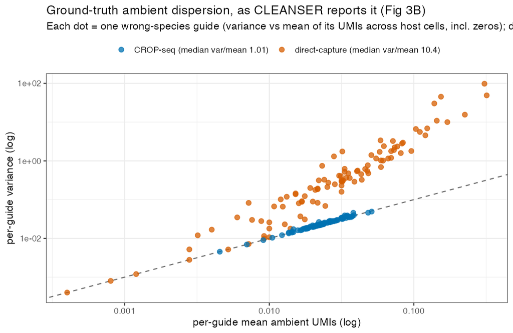

Per wrong-species guide, the variance vs the mean of its UMI counts across host cells (each dot is one guide; the dashed line is variance = mean, i.e. Poisson). Direct-capture (orange) sits an order of magnitude above the Poisson line; CROP-seq (blue) sits on it. This reproduces CLEANSER’s Figure 3B from the raw barnyard counts.

For a Poisson the variance/mean should be ≈ 1 — where CROP-seq sits — whereas direct-capture is ≈ **10**. Taken at face value the direct-capture soup looks over-dispersed. It is not — and seeing *why* is worth the two steps below, because it says CLEANSER’s observation is real but its interpretation adds a parameter that the data do not require. **This complements CLEANSER’s analysis rather than contradicting it.**

A variance/mean ratio lumps together everything that makes counts spread. Two ordinary effects do so here, and neither means the soup itself is over-dispersed: **cell doublets** and **cell-to-cell variation in ambient depth**. We take them in turn — and the first one turns out to hinge on a QC threshold that is usually set too loosely.

## 2.3 Most of the over-dispersion is doublets — and the standard purity gate is too loose

Two cells occasionally land in one droplet. A human droplet that also caught mouse material carries mouse-guide UMIs that have nothing to do with the soup — a few large wrong-species counts that, being squared, dominate the variance. The standard defense is a **GEX-purity gate**: keep a cell only if its gene-expression is almost entirely one species. CLEANSER (and most pipelines) use a **0.90** threshold. But 0.90 is too loose. Plotting the *mouse* fraction of each cell’s gene-expression on a **log axis** shows why (a log axis resolves the human cells, which are all bunched near zero mouse-GEX):

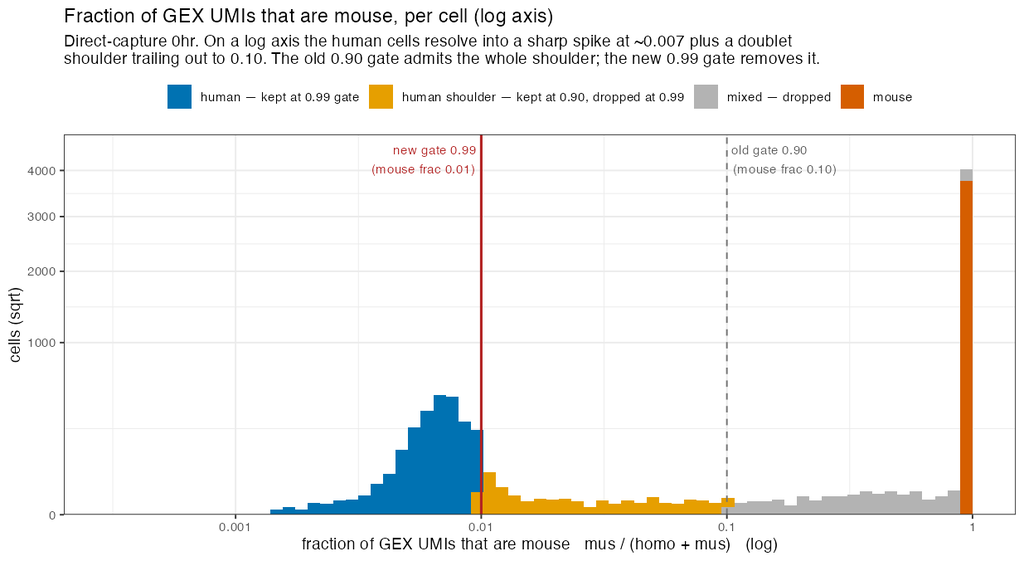

Fraction of each cell’s gene-expression UMIs that are mouse, per cell, on a log axis (direct-capture 0hr; sqrt y). The human cells form a sharp spike at ~0.007 mouse-GEX (blue); a shoulder of minority-partner doublets (gold) trails out to 0.10. The old 0.90 gate (grey dashed, at mouse fraction 0.10) admits the whole shoulder; the new 0.99 gate (red, at mouse fraction 0.01) removes it. Mouse cells (orange) sit at the far right.

The genuine human cells form a tight spike at ~0.007 mouse-GEX (frac_homo ≈ 0.993); to its right, a broad shoulder of **minority-partner doublets** trails out to 0.10 mouse-GEX (frac_homo 0.90) — droplets that are mostly one cell plus a smaller partner of the other species. The 0.90 gate lets the whole shoulder through. **Moving the gate to 0.99** (which costs only **9% of cells**: 2499 → 2277) removes it, and the ambient variance drops onto the Poisson line:

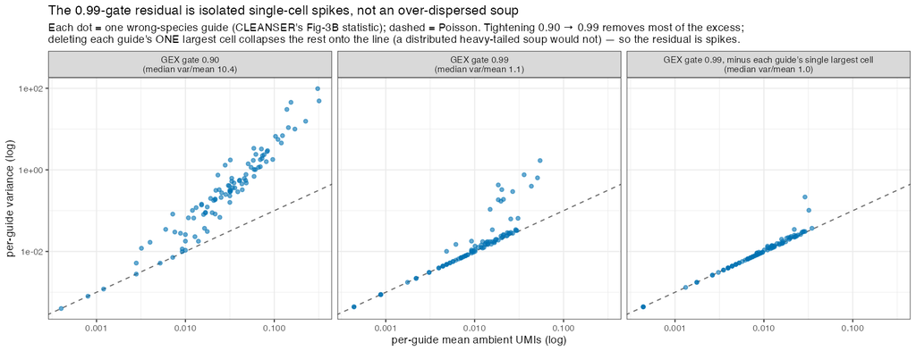

Per wrong-species guide, variance vs mean across host cells (CLEANSER’s Fig-3B statistic); dashed = Poisson. Left → middle: tightening the gate 0.90 → 0.99 pulls the per-guide median var/mean from 10.4 to 1.1. Right: a non-circular check of the dozen-odd guides still above the line at 0.99 — deleting each guide’s *single largest cell* collapses them onto the line (median var/mean → 1.0). A genuinely over-dispersed soup is a *distributed* heavy tail and would barely move; the collapse shows the residual is instead **isolated single-cell spikes**.

The per-guide median variance/mean — CLEANSER’s exact statistic — falls from **10.4 to 1.1**. So the bulk of the “direct-capture over-dispersion” was simply doublets the conventional 0.90 gate let through. And the handful of guides still above the line at 0.99 are **not** a residual over-dispersed *soup*: a soup would be a distributed heavy tail, but deleting each guide’s single largest cell collapses them straight onto the Poisson line (right panel, median var/mean → 1.0). That could only happen if the excess lives in **one cell per guide** — isolated spikes, not soup. (CROP-seq sits at var/mean ≈ 1.0 regardless — it never had the doublet problem, because its poly-A capture doesn’t produce these spikes.)

## 2.4 GEX can’t quite finish the job — a soup floor, and five stubborn cells

Tightening to 0.99 does not get all the way to var/mean = 1, though: the *pooled* value is still 4.8, held up by a **handful of spike cells** that survive the gate. (Because each such debris cell carries *several* mouse guides at once, these few cells are what put the ~dozen guides above the line in the right panel above; the **five** clearest — those with a spike ≥ 10 UMIs — are tabulated below.) And you cannot fix this by tightening GEX further, because **GEX purity has a ceiling.** Even a perfectly clean 293T cell carries ~0.7% mouse-mRNA *soup*, so frac_homo tops out around 0.998 (median 0.993); a 0.995 gate already discards **90%** of the cohort, and 0.999 keeps essentially none. So GEX runs out of room right where these spike cells live. What are they? Each row below is one **droplet** (cell), labeled by the single mouse guide that spikes in it — and all five spike a *different* guide, i.e. five independent contamination events, not one guide misbehaving:

| cell | spiking mouse guide | wrong-species count | human-GEX fraction | mouse mRNA UMIs | human mRNA UMIs | total gRNA |
| --- | --- | --- | --- | --- | --- | --- |
| 1 | nt_176 | 58 | 0.9937 | 33 | 5185 | 121 |
| 2 | nt_131 | 41 | 0.9913 | 134 | 15292 | 147 |
| 3 | nt_143 | 27 | 0.9928 | 63 | 8633 | 2581 |
| 4 | nt_101 | 15 | 0.9919 | 104 | 12794 | 48 |
| 5 | nt_106 | 12 | 0.9924 | 64 | 8331 | 143 |

Each is a GEX-clean human droplet (human-GEX fraction > 0.99) carrying one loud mouse guide (12–58 UMIs). Against a baseline of ~66 mouse-mRNA UMIs in clean human cells, they split into two kinds:

- **Tiny minority-partner doublets** — cells 2 and 4 (spiking nt_131 and nt_101) have *elevated* mouse mRNA (134, 104), i.e. a small co-encapsulated mouse cell or fragment — too minor to move the GEX fraction below 0.99, but enough to bring a real mouse guide.
- **gRNA-only artifacts** — the other three (cell 1 / nt_176: a 58-UMI spike but only 33 mouse mRNA, *below* baseline; cell 3 / nt_143: 27 UMIs; cell 5 / nt_106: 12 UMIs) each carry a loud mouse-guide *spike* with mouse mRNA at or below baseline — no accompanying mouse transcriptome. The spike is chimeric / index-hopped reads: a mouse guide’s molecules landing on a human barcode. (Cell 3’s droplet is itself a strongly guide-carrying human cell — total gRNA 2,581 — with the mouse spike riding on top.)

Both kinds are **GEX-invisible by construction** — they barely perturb the transcriptome — which is exactly why no GEX threshold can catch them. They are removed on the *gRNA* side instead (fishash’s own carrier-masking flags a several-UMI spike in an otherwise-shallow cell and holds it out of the ambient fit). This is the honest reason “GEX purity didn’t fully work”: it’s not that 0.90 was a badly chosen number, it’s that the mouse-mRNA soup floor caps GEX resolution at ~0.998, and the last few contaminants live inside that ceiling.

## 2.5 What genuinely remains is depth-mixing, not soup over-dispersion

With the doublet shoulder gated out (0.99), the wrong-species counts on guides free of an offender spike are *pure ambient* — and they are still not a *single* Poisson. The reason is benign: the ambient rate $a_g d_c$ differs from cell to cell (the depth $d_c$ varies), so a guide’s marginal is a *mixture* of Poissons, which sits mildly above var/mean = 1 even though every individual cell is exactly Poisson. This is captured by modeling the rate per cell — **a depth-mixed Poisson** — with no dispersion parameter. The fit is visible directly in each guide’s histogram:

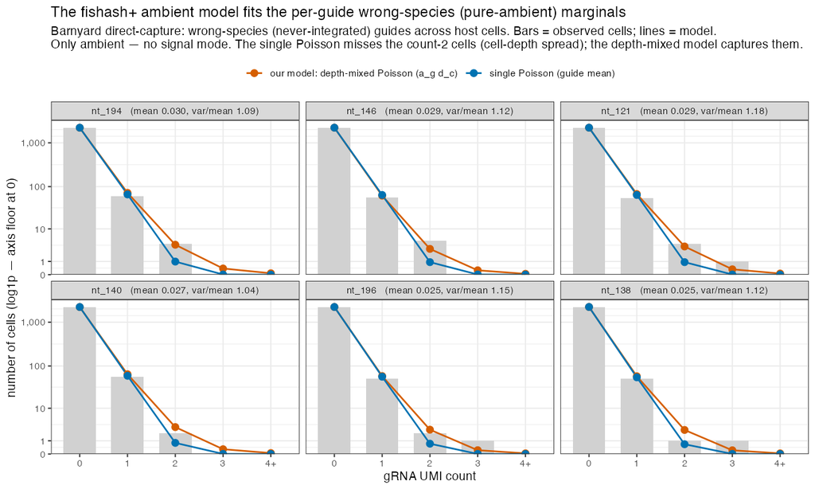

Six wrong-species (never-integrated) guides, direct-capture, GEX gate 0.99. Bars are observed cell counts; orange is the depth-mixed Poisson (rate $a_g d_c$ per cell); blue is a single Poisson at the guide’s mean. The whole histogram is ambient (no signal mode). The single Poisson misses the count-2 cells; the depth-mixed model matches them.

Both models trivially match counts 0 and 1, but at **count 2** the single Poisson falls short while the depth-mixed model lands on the observed bar — those count-2 cells come from the high-depth tail, which only a per-cell rate reproduces (Pearson $\chi^2$, smaller = better):

| guide | mean ambient count | variance / mean | chi-sq: depth-mixed Poisson | chi-sq: single Poisson |
| --- | --- | --- | --- | --- |
| nt_194 | 0.030 | 1.09 | 2.4 | 9.8 |
| nt_146 | 0.029 | 1.12 | 2.4 | 18.9 |
| nt_121 | 0.029 | 1.18 | 3.9 | 120.9 |
| nt_140 | 0.027 | 1.04 | 1.6 | 1.9 |
| nt_196 | 0.025 | 1.15 | 3.9 | 164.4 |
| nt_138 | 0.025 | 1.12 | 4.6 | 180.0 |

**Conclusion.** CLEANSER’s over-dispersion was real, but it decomposes cleanly: **doublets** — mostly excluded by a properly-tightened GEX gate (0.99), the last handful GEX-invisible and cleaned on the gRNA side — plus **depth-mixing**, a Poisson with a per-cell rate. Neither calls for an over-dispersed soup. The Poisson rate model $a_g d_c$ is the right null in both chemistries, and it is the null the method below is built on.

# 3 The method: fishash, and one change that makes fishash+

## 3.1 fishash

The strongest published method on this problem is **fishash**. It turns the ambient-rate model into a per-entry test with two ideas worth stating plainly. First, it estimates the ambient rate $a_g d_c$ not from the raw data (which is contaminated by the very integrations we are trying to find) but from a **denoised** version, in which cells confidently carrying a guide are masked out before the rate is re-estimated. Second, it tests each entry with a **contingency-table** (hypergeometric) test rather than a plug-in Poisson tail. Because that test conditions on the table’s row and column totals, it does not lean on an externally-estimated rate, and it corrects a subtle bias — a Simpson’s-paradox effect, in which signal pooled into the table’s background cells can, on its own, tip the odds ratio and manufacture a false positive. The two ideas run in a short loop:

**Algorithm — fishash (and fishash+)**

Input: guide × cell count matrix $N$; FDR level $q$. Repeat until the set of called integrations stops changing:

1. **Estimate the ambient rate.** Mask the entries currently called as integrations; fit a rank-1 Poisson — the $a_g d_c$ outer-product model of §1 — to what remains, giving an ambient rate for every (guide $g$, cell $c$), where $a_g$ = guide’s soup share and $d_c$ = cell’s ambient depth.
2. **Test every entry.** For each (guide $g$, cell $c$), test whether $N_{g,c}$ is larger than its ambient rate would allow, with a one-sided hypergeometric test on the 2×2 table {guide $g$ vs. other guides} × {cell $c$ vs. other cells}, using the *denoised* background from step 1.
3. **Assign.** Reject at FDR level $q$ (Guo–Sarkar, each cell a block); the rejected entries become the updated set of integrations.

## 3.2 The one change: fishash+

Step 2 asks how large $N_{g,c}$ is *relative to how much of the cell’s readout could be ambient* — the cell’s “exposure.” fishash uses the cell’s **raw total gRNA count** for that exposure. This is the one place it can be improved. In a cell that carries a strongly-expressed guide, the raw total is dominated by that guide’s own signal, which has nothing to do with the soup. Using it over-states the ambient exposure, so a real but weaker second guide in the same cell looks unremarkable and is missed — the test effectively **masks the cell with its own dominant guide.** This costs recall exactly when cells carry several guides (high MOI).

**fishash+ changes one thing:** it uses the **denoised ambient depth $d_c$** — already computed in step 1 — as the cell’s exposure, instead of the raw total. Nothing else differs. This removes the self-masking while leaving every other property of fishash intact.

## 3.3 Benchmarks

On the barnyard ground truth, fishash+ **matches** fishash (both lead the published alternatives). Barnyard is low-MOI, so there is little self-masking to undo — the point here is *no regression* on ground-truth accuracy:

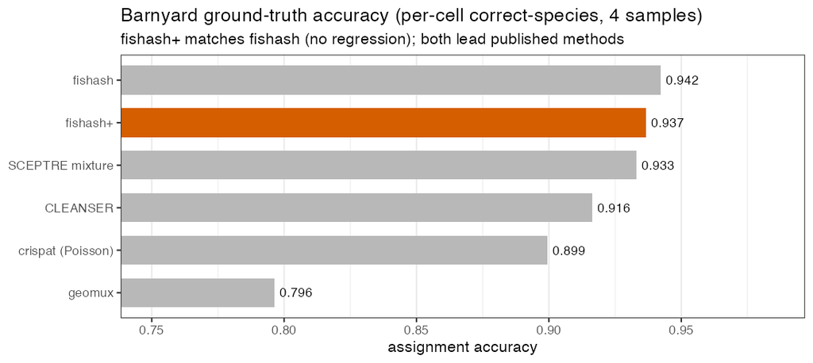

Assignment accuracy on the barnyard ground truth (the standard per-cell “correct species” metric), averaged over the four barnyard samples. fishash+ (0.937) matches fishash (0.942), and both lead the published methods. Our fishash reproduction reproduces the published fishash number exactly, so the scales are directly comparable.

The advantage appears as MOI rises and cells carry co-occurring guides. In simulation, fishash’s recall falls off with MOI as self-masking bites, while fishash+ holds up — recovering ~10 percentage points of recall at MOI 5, at negligible cost to the false-discovery rate:

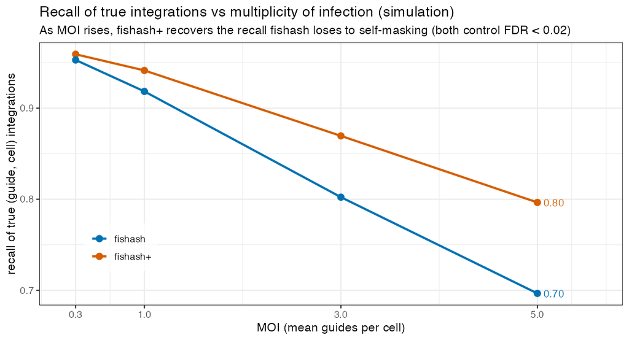

Recall of true (guide, cell) integrations vs. MOI, in simulation. As MOI rises, fishash+ recovers the recall fishash loses to self-masking; both control the false-discovery rate below 0.02 at every MOI.

So fishash+ is fishash’s well-validated core with its one blind spot removed: identical where MOI is low, better where it is high. (The full generative model this test derives from, and its relation to CLEANSER and geomux, is in `canonical_model.html`.)

# 4 The lower count mode is partly real

The barnyard settles the null on *provable* ambient. Real screens are harder, and raise a question the benchmark cannot: when a guide’s counts split into a **low mode** (presumed contamination) and a **high mode** (clear integrations), is the low mode really all contamination?

We look at Replogle et al.’s genome-scale K562 screen (direct capture, CRISPR interference). Most guides have overlapping low and high modes, but a minority have a **completely empty gap** between them, which lets us isolate the low mode cleanly. Guide **RAMAC** is the clearest: counts 1–7, then *no cells at all* from 8 to 69, then a broad high mode from 70 up. The empty gap is itself informative — it means these are two genuinely distinct populations, not one smooth heavy tail.

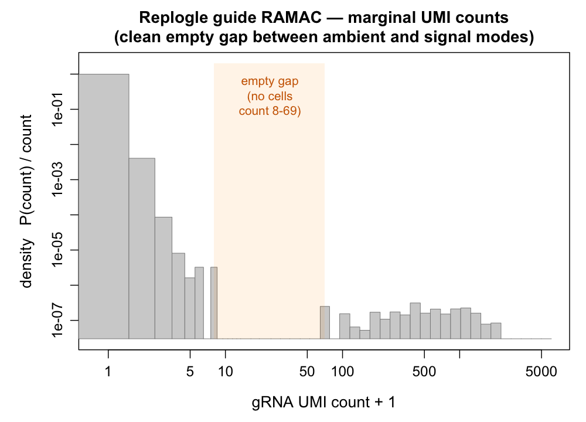

RAMAC’s full count distribution: a low (ambient) mode at 1–7, a completely empty gap at 8–69, then a broad high (signal) mode from 70 up. Two distinct populations.

Fitting the low mode with the depth-mixed Poisson (the ambient model validated above), it explains counts 0 and 1 essentially perfectly — but leaves a real excess at count 2 (≈9 cells predicted, 53 observed):

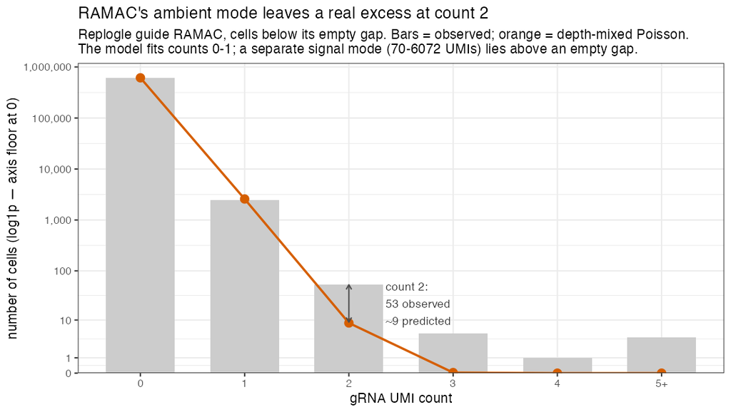

RAMAC’s low mode with the depth-mixed Poisson (orange). The model fits counts 0–1 but under-predicts count 2 by ~6× (9 predicted vs. 53 observed). This residual is the question: contamination the model misses, or something real?

Is that residual over-dispersed contamination, or real signal hiding in the low counts? The barnyard answers it directly. On *provable* soup — the wrong-species guides — the same count-2 diagnostic sits exactly at the **depth-mixed Poisson** prediction (observed/expected ≈ 0.9), because provable soup contains no integrations to inflate it. So the Replogle excess is **not** contamination. It is signal.

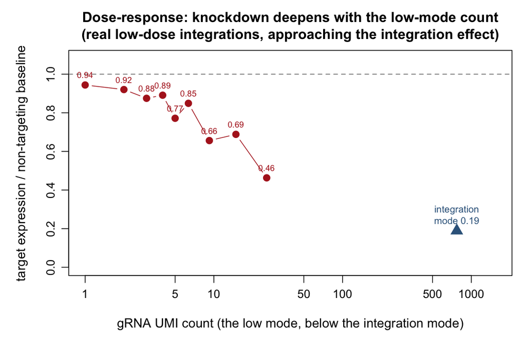

Contamination cannot knock down a gene. So the low mode is a **mixture**: mostly contamination, plus a real minority of cells carrying a genuine but weakly-expressed guide. Across Replogle’s clean-gap guides, that real minority is about 15% of the low-mode excess cells; the rest are background.

# 5 It generalizes, and depends on the soup

The same dose-response appears in every dataset with resolvable modes and a measured target gene — EndoC and CD4 T-cell as well as Replogle (`global_ambient_poisson.html`). What *does* vary across datasets is **how much** of the low mode is real, and it varies in an interpretable way: the denser the soup, the more of the low mode is genuine contamination; the thinner the soup, the more of it is real weak integration. Strong integrations knock down everywhere (~0.2, so the readout has power in each dataset), but the low mode’s functional fraction climbs as the soup thins:

| dataset | guides tested | knockdown: strong integrations | knockdown: low mode | low mode: functional fraction |
| --- | --- | --- | --- | --- |
| tcell | 259 | 0.20 | 0.64 | 0.45 |
| replogle_rd7 | 104 | 0.17 | 0.87 | 0.15 |
| endoc | 56 | 0.19 | 0.94 | 0.08 |

In the dense-soup EndoC screen the low mode is ~8% real (essentially all contamination); in Replogle ~15%; in the genome-scale, thin-soup CD4 T-cell screen ~45% — nearly half the low-mode cells carry a real guide. There is no single answer to “is the low mode contamination or signal”: **it depends on the soup density.**

# 6 What the weak integrations are

The dose-response says the low-mode cells carry a *functional* guide at low abundance. The most likely mechanism is **position-effect silencing of the integrated guide cassette.** Lentiviral integration lands in a semi-random genomic location, and expression from the integrated cassette depends strongly on where it lands: an integration into transcriptionally quiet or heterochromatic DNA is partially silenced, so the cell makes *less* guide — a low count — while still making enough to drive real target knockdown. Two further effects point the same way: **low integration copy number** (a single, recent, or poorly-expressed copy), and the **noisier capture** of the direct-capture chemistry, which spreads genuine integrations to lower and more variable counts. All three produce exactly what we observe: cells that are real integrations but sit low in the count distribution.

# 7 What this means for guide assignment

Guide assignment ultimately asks a biological question: **did this cell receive a functional guide?** By that definition, a low-mode cell that demonstrably knocks down its target *does* have the guide, and calling it is correct, not a false positive. The low mode is not a calibration failure to be suppressed — part of it is exactly the signal we want.

So the real decision is not about calibration but about **what one wants to measure**, and it is a genuine trade-off because the low mode is a mixture:

- To **maximize recall of perturbed cells** (e.g. calling which cells to include for a hit), reach into the low mode.
- To get the **cleanest effect-size estimate** (e.g. quantitative downstream modeling), stay in the high mode, since the contamination in the low mode dilutes the estimate.

Both are served by the *same* Poisson model plus one knob — the detection floor (a minimum count, or the FDR level $q$) — set according to the downstream task and the dataset’s soup density. Crucially, this is a knob on the estimand, **not** a reason to inflate the null: fitting an over-dispersed (negative-binomial) soup would absorb the real weak integrations into the “noise” and suppress the very signal we have shown is there. The Poisson null is correct; keep it, and choose the floor deliberately.

The ultimate arbiter — how far into the low mode to reach — is downstream differential-expression calibration and power under each assignment, which prices the recall/precision trade directly; that evaluation is scoped and in progress (`SIMULATION_FRAMEWORK.md`).

## Where the full analyses live

This note is a self-contained synthesis; each result has a fully-computed backing document.

| Topic | Document |
| --- | --- |
| Ambient is Poisson; doublet + depth decomposition; formal goodness-of-fit | `doublet_overdispersion.html` |
| The generative model behind the test; fishash / CLEANSER / geomux as special cases | `canonical_model.html` |
| The methods landscape | `literature_review.html` |
| Replogle clean-gap case study; the decisive soup test | `replogle_ambient_poisson.html` |
| Global clean-gap cohort; knockdown dose-response across datasets | `global_ambient_poisson.html` |
| Full method benchmarks (barnyard, simulations) | `sceptre3_assignment_report.html`, `simulation_framework_report.html` |